# analitica-ais

[figure not shown]

### En primer lugar se crea la sesión de Spark, importamos los módulos requeridos, incluido GeoAnalytics Engine

```python
import geoanalytics
import matplotlib.pyplot as plt
from IPython.display import display, HTML
import geoanalytics.sql.functions as ST
from geoanalytics.tools import AggregatePoints
from geoanalytics.tools import FindDwellLocations
from geoanalytics.tools import ReconstructTracks
from pyspark.sql.functions import *
from pyspark.sql import functions as F

geoanalytics.version()
geoanalytics.auth(username="gaengine_esri_es", password="3^Sh!5VQy2oQ")
```

```
VBox()
```

```
Starting Spark application
```

| ID | YARN Application ID | Kind | State | Spark UI | Driver log | User | Current session? |
| --- | --- | --- | --- | --- | --- | --- | --- |
| 3 | application_1687170204122_0004 | pyspark | idle | [Link](http://ip-172-31-16-144.eu-west-1.compute.internal:20888/proxy/application_1687170204122_0004/) | [Link](http://ip-172-31-28-174.eu-west-1.compute.internal:8042/node/containerlogs/container_1687170204122_0004_01_000001/livy) | None | ✔ |

```
FloatProgress(value=0.0, bar_style='info', description='Progress:', layout=Layout(height='25px', width='50%'),…
```

```
SparkSession available as 'spark'.
```

```
FloatProgress(value=0.0, bar_style='info', description='Progress:', layout=Layout(height='25px', width='50%'),…
```

### Vamos a utilizar ficheros de posiciones de barcos (AIS)

```python
%%HTML
<iframe src="https://www.arcgis.com/apps/mapviewer/index.html?webmap=40a6b0c62ff046df8218a32421c85143" \
style="border:0px #ffffff none;" name="myiFrame" scrolling="no" frameborder="0" marginheight="0px" marginwidth="0px" \
height="650px" width="1500px" allowfullscreen></iframe>
```

[interactive chart not shown]

### Leeemos los ficheros parquet de S3 correspondientes a 1 mes de datos

- Se leen todos los ficheros de 1 mes completo, que corresponden a **10GB de datos en formato parquet (unos 50GB en el formato original CSV)**, cada fichero contiene **más de 10 millones de posiciones AIS**.
- Mediante las capacidades de GeoAnalytcis Engine **indicamos al dataframe Spark que campos corresponden a la geometría y al tiempo, así como el sistema de referencia espacial**.

https://s3.console.aws.amazon.com/s3/buckets/ga-engine-esri-es?region=eu-west-1&prefix=v2/&showversions=false

```python
df = spark.read.parquet("s3://ga-engine-esri-es/v2/*.parquet") \
.selectExpr("*", "ST_Point(Longitude, Latitude, 4326) as SHAPE").st.set_geometry_field("SHAPE"). \
withColumn("timestamp", to_timestamp('#Timestamp', "dd/MM/yyyy HH:mm:ss")).st.set_time_fields("timestamp")

rows = df.count()
print(f"Numero de filas : {rows:,}")
cols = len(df.columns)
print(f"Numero de columnas : {cols}")
```

```
VBox()
```

```
FloatProgress(value=0.0, bar_style='info', description='Progress:', layout=Layout(height='25px', width='50%'),…
```

```
Numero de filas : 317,981,590
Numero de columnas : 28
```

### Este dataframe contiene más de 300 millones de registros

Con herramientas tradicionales la generación de este dataframe nos podría llevar horas y lo hemos hecho en segundos

El contenido del dataframe de Spark es el siguiente:

```python
%%display
df.coalesce(1).limit(5)
```

```
FloatProgress(value=0.0, bar_style='info', description='Progress:', layout=Layout(height='25px', width='50%'),…
```

```
VBox(children=(HBox(children=(HTML(value='Type:'), Button(description='Table', layout=Layout(width='70px'), st…
```

```
Output()
```

### Seguidamente vamos a transformar la geometría a un sistema de referencia espacial proyectado para una mejor visualización (Web Mercator)

```python
df_proyectado = df.withColumn("SHAPE", ST.transform("SHAPE", 3857))

rows = df.count()
print(f"Numero de filas : {rows:,}")
```

```
VBox()
```

```
FloatProgress(value=0.0, bar_style='info', description='Progress:', layout=Layout(height='25px', width='50%'),…
```

```
Numero de filas : 317,981,590
```

El nuevo dataframe tiene el mismo aspecto pero el campo shape contiene las coordenadas en web mercator.

```python
%%display
df_proyectado.coalesce(1).limit(5)
```

```
FloatProgress(value=0.0, bar_style='info', description='Progress:', layout=Layout(height='25px', width='50%'),…
```

```
VBox(children=(HBox(children=(HTML(value='Type:'), Button(description='Table', layout=Layout(width='70px'), st…
```

```
Output()
```

## Pero lo realmente interesante es obtener conclusiones a partir de estos datos con las capacidades proporcionadas por GeoAnalytics Engine

- En primer lugar, **agruparemos los puntos de acuerdo a bins hexagonales**

  GeoAnalytics Engine nos proporcionará la **información agregada (map-reduce) para que pueda ser manejada sin problema alguno debido a su volumen**.

#### Realizamos la agregación, la cual se ejecuta de manera ágil en un corto periodo de tiempo

Generamos agrupaciones hexagonanes con un **tamaño de bin del 1km** mediante la funcion `AggregatePoints`.

[Documentación](https://developers.arcgis.com/geoanalytics/tools/aggregate-points/)

```python
result = AggregatePoints().setBins(bin_size=1000, bin_size_unit="Meters",bin_type="Hexagon").run(df_proyectado)

rows = result.count()
print(f"Numero de filas : {rows:,}")
cols = len(result.columns)
print(f"Numero de columnas : {cols}")
```

```
VBox()
```

```
FloatProgress(value=0.0, bar_style='info', description='Progress:', layout=Layout(height='25px', width='50%'),…
```

```
Numero de filas : 726,234
Numero de columnas : 2
```

- **Se ha reducido el tamaño del dataframe a 726 mil filas con geometría hexagonal**, donde para cada fila se muestra la suma de puntos que agrupa.
- La capacidad del cluster influyen enormemente en el tiempo de ejecución de tareas como esta.
- 2 nodos de procesamiento tarda 6 minutos en ejecutar la agregación y contar las filas.
- 7 nodos tarda ligeramente más de 1 minuto en ejecutar la agregación y contar las filas
- Existen otras operaciones más allá de la suma, por ejemplo el valor medio, varianza, desviación estándar, etc.

[Documentación](https://developers.arcgis.com/geoanalytics/tools/aggregate-points/)

#### Visualización del contenido del dataframe con los bins hexagonales 1km

```
VBox()
```

```
FloatProgress(value=0.0, bar_style='info', description='Progress:', layout=Layout(height='25px', width='50%'),…
```

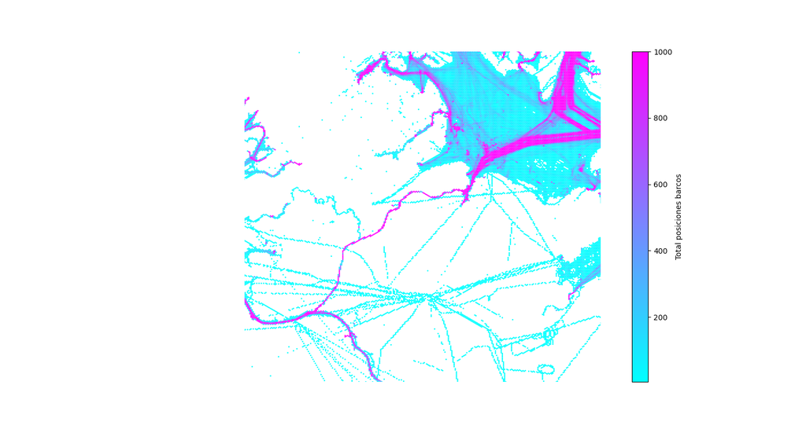

```python
axes=result.st.plot(cmap_values="COUNT", cmap="cool", vmax=1000, vmin=5, figsize=(15, 8), legend=True, legend_kwds={"label": "Total posiciones barcos"})
axes.set(xlim=(964023.8007, 1232776.3922), ylim=(7095535.0835, 7345305.4549), frame_on=False, xticks=[], yticks=[])
%matplot plt
```

#### Integración con ArcGIS Enterprise y ArcGIS Online

Adicionalmente, mediante la **ArcGIS API for Python** podemos aprovechar nuestra infraestructura de ArcGIS Enteprise y/o ArcGIS Online para actualizar un feature service y mantener el servicio actualizado con la última versión de los datos cada vez que se ejecute el pipeline de procesamiento

```python
%%HTML
<iframe src="https://www.arcgis.com/apps/mapviewer/index.html?webmap=eca61955862a4789b752e4c8595765c4" \
style="border:0px #ffffff none;" name="myiFrame" scrolling="no" frameborder="0" marginheight="0px" marginwidth="0px" \
height="650px" width="1500px" allowfullscreen></iframe>
```

[interactive chart not shown]

## Detección de anomalías en una zona de interés

#### Vamos a ir un poco más allá en el análisis de los datos

- Nos centraremos en una zona específica de interés, filtrando el resto de información. Para ello definimos un bounding box entorno al puerto de Flensburg mediante `ST_EnvIntersects`.
- Filtramos los datos del dataframe de partida para quedarnos únicamente con los que se encuentran en ese entorno, tanto el entorno como los campos de interés.

```python
boundingbox = df.selectExpr("Name", "SHAPE", "Callsign","timestamp",\
"ST_EnvIntersects(SHAPE,9.4334270,54.7943501,9.4386438,54.7872229) as Filter")
port = boundingbox.filter(boundingbox['Filter'] == True)
rows = port.count()
print(f"Numero de filas : {rows:,}")
cols = len(port.columns)
print(f"Numero de columnas : {cols}")
```

```
VBox()
```

```
FloatProgress(value=0.0, bar_style='info', description='Progress:', layout=Layout(height='25px', width='50%'),…
```

```
Numero de filas : 109,980
Numero de columnas : 5
```

```python
result_dwell = FindDwellLocations().setTrackFields("Callsign").setDistanceMethod(distance_method="Planar").\
setDwellMaxDistance(max_distance=10, max_distance_unit="Meters").\
setDwellMinDuration(min_duration=12, min_duration_unit="hours").\
setOutputType(output_type="DwellMeanCenters").run(dataframe=port)

rows = result_dwell.count()
print(f"Numero de filas : {rows:,}")
cols = len(result_dwell.columns)
print(f"Numero de columnas : {cols}")
```

```
VBox()
```

```
FloatProgress(value=0.0, bar_style='info', description='Progress:', layout=Layout(height='25px', width='50%'),…
```

```
Numero de filas : 58
Numero de columnas : 10
```

```python
%%display
result_dwell.coalesce(1)
```

```
FloatProgress(value=0.0, bar_style='info', description='Progress:', layout=Layout(height='25px', width='50%'),…
```

```
VBox(children=(HBox(children=(HTML(value='Type:'), Button(description='Table', layout=Layout(width='70px'), st…
```

```
Output()
```

```python
%%HTML
<iframe src="https://www.arcgis.com/apps/mapviewer/index.html?webmap=1d6ddc8c4f464f8aa41d114ebe1afd30" \
style="border:0px #ffffff none;" name="myiFrame" scrolling="no" frameborder="0" marginheight="0px" marginwidth="0px" \
height="650px" width="1500px" allowfullscreen></iframe>
```

[interactive chart not shown]

### Finalmente para estos barcos de interés reconstruimos sus rutas

- Filtramos, de los **más de 300 millones de localizaciones AIS las que corresponden a barcos/dispositivos que se han localizado en el puerto de Flensburg**.
- Mediante `Reconstruct tracks` vamos a **construir las rutas** por las que se han estado moviendo. **Generaremos una ruta por cada barco (formalmente cada dispositivo hardware AIS, atributo Callsign) y para cada 24 horas**.

```python
distinct_column = 'Callsign'


distinct_column_vals = port.select(distinct_column).distinct().collect()
dcv = []
for v in distinct_column_vals:
    v = str(v)
    a = v.split("=")
    dcv.append(str(a[1])[1:-2])

poi = df.filter(F.col("Callsign").isin(dcv))

boundingbox = poi.selectExpr("Name", "SHAPE", "Callsign","timestamp",\
"ST_EnvIntersects(SHAPE,-4.781244,49.724480,34.989264,67.135830) as Filter")

poiarea = boundingbox.filter(boundingbox['Filter'] == True)

tracks = ReconstructTracks().setTrackFields("Callsign").setDistanceMethod(distance_method="Planar")\
.setTimeBoundarySplit(time_boundary_split=24, time_boundary_split_unit='Hours', time_boundary_reference=None)\
.run(dataframe=poiarea)

rows = tracks.count()
print(f"Numero de filas : {rows:,}")
```

```
VBox()
```

```
FloatProgress(value=0.0, bar_style='info', description='Progress:', layout=Layout(height='25px', width='50%'),…
```

```
Numero de filas : 689
```

### Resultado de ejecutar la reconstrucción de rutas

```python
%%display
tracks.coalesce(1).limit(5)
```

```
FloatProgress(value=0.0, bar_style='info', description='Progress:', layout=Layout(height='25px', width='50%'),…
```

```
VBox(children=(HBox(children=(HTML(value='Type:'), Button(description='Table', layout=Layout(width='70px'), st…
```

```
Output()
```

```
VBox()
```

```
FloatProgress(value=0.0, bar_style='info', description='Progress:', layout=Layout(height='25px', width='50%'),…
```

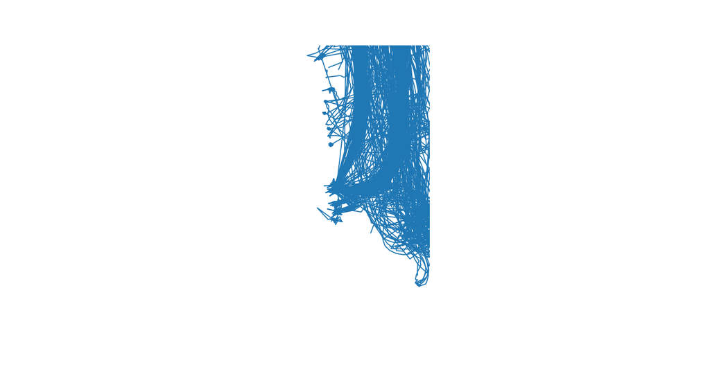

```python
axes=tracks.st.plot( figsize=(15, 8),legend=False)
axes.set(xlim=(9.4334270, 9.4366438), ylim=(54.7872229, 54.7943501), frame_on=False, xticks=[], yticks=[])
%matplot plt
```

### Del mismo modo podemos cargar los tracks en ArcGIS Enteprise o ArcGIS Online

```python
%%HTML
<iframe src="https://www.arcgis.com/apps/mapviewer/index.html?webmap=fe786e941ff44343991c5653b7a00f4b" \
style="border:0px #ffffff none;" name="myiFrame" scrolling="no" frameborder="0" marginheight="0px" marginwidth="0px" \
height="650px" width="1500px" allowfullscreen></iframe>
```

[interactive chart not shown]

### Finalmente, filtramos un barco de interés para obtener los tracks del mismo para toda la serie de datos

```python
df_barco= df_proyectado.filter(df["CALLSIGN"] == 'DDGU')

rows = df_barco.count()
print(f"Numero de filas : {rows:,}")

tracks_df_barco = ReconstructTracks().setTrackFields("CALLSIGN").setDistanceMethod(distance_method="Planar")\
.setTimeBoundarySplit(time_boundary_split=24, time_boundary_split_unit='Hours', time_boundary_reference=None)\
.run(dataframe=df_barco)

rows = tracks_df_barco.count()
print(f"Numero de filas : {rows:,}")
```

```
VBox()
```

```
FloatProgress(value=0.0, bar_style='info', description='Progress:', layout=Layout(height='25px', width='50%'),…
```

```
Numero de filas : 70,702
Numero de filas : 30
```

- Representamos los tracks del barco seleccionado, **combinado con informacióndel Living Atlas**.
- Visualizamos la zona recorrida por el barco seleccionado durante el último mes.

```
VBox()
```

```
FloatProgress(value=0.0, bar_style='info', description='Progress:', layout=Layout(height='25px', width='50%'),…
```

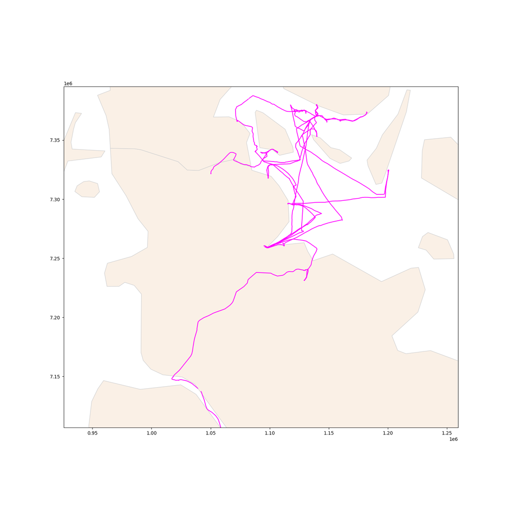

```python
url = "https://services.arcgis.com/d3voDfTFbHOCRwVR/arcgis/rest/services/Europe_contours_pays/FeatureServer/0"
paises_europa = spark.read.format("feature-service").load(url)

axes = paises_europa.st.plot(facecolor="linen", edgecolor="lightgray", figsize=(15, 15), aspect="equal")
axes.set(xlim=(925639, 1259471), ylim=(7106784, 7395357))

tracks_df_barco.st.plot(ax=axes, aspect="equal", edgecolor="magenta")

%matplot plt
```

### Con ArcGIS GeoAnalytics Engine, hemos podido:

- **Trabajar de manera agil y rápida con cientos de millones de registros directamente desde el data lake en formato parquet** y habilitado las propiedades espacio y tiempo en un dataframe de Spark. Ahorrando un tiempo incalculables a los ingenieros y científicos de datos, para centrarse en analizar los resultados en lugar de, simplemente, llevar los datos a donde deben estar.
- **Agregar los datos en bins hexagonales y visualizarlos** para entender su distribución espacial y patrones iniciales. Permitiendo a los analistas utilizar su experiencia en la materia para evaluar sus consultas de seguimiento en función de las limitaciones de datos, anomalías o tendencias que identifiquen en esta fase exploratoria.
- **Filtrar espacialmente nuestro masivo conjunto de datos utilizando un bounding box** para delimitar una zona de interés. Permitiendo a los analistas concentrarse rápidamente solo en aquellas ubicaciones que son más importantes para sus misiones.
- **Localizar aquellos barcos que han parado prolongadamente en un área de interés**.
- **Reconstruir las rutas de los barcos que habían parado en nuestra area de interés**. Construyendo un patrón más amplio de actividades.
- **Reconstruir las rutas para un barco en particular** a partir de toda la serie de datos disponibles

### Quizás la mejor parte es que todo esto puede automatizarse y ejecutarse como una tarea programada como parte de los pipelines de big data y business intelligence de la organización, aprovechando la infraestructura propia transversal a la organización.

- Al correr sobre Spark, toda la capacidad demostrada, y **la capacidad completa de la librería, puede ser incorporada a los pipelines de big data y analítica en un entorno familiar para los ingenieros y científicos de datos, ya que GeoAnalytics Engine "habla" su idioma**.
- Los analistas y los responsables de la toma de decisiones pueden consumir las visualizaciones y los resultados que produce GeoAnalytics Engine **sin ver una línea de código.**